# Statistical Inference Course Project Part1

by jordiac , December 2016

### Synopsis

This is the Course Project of Statistical Inference module from Data Scientist course.

The project aims to analyze the Exponential distribution and compare it with the Normal distribution via 2 main exercises:

```
    1.Simulation exercise
    2.Inferential data analysis
```

### Ex. 1: Simulation

-The exponential distribution can be simulated in R with rexp(n, lambda) where lambda is the rate parameter. The mean of exponential distribution is 1/lambda and the standard deviation is also 1/lambda. Set lambda = 0.2 for all of the simulations.

-The following is based on the simulation of the distribution of averages of 40 exponentials (doing a thousand simulations).

-This first exercise shall treat the following points:

```
    1.Show the sample mean and compare it to the theoretical mean of the distribution.
    2.Show how variable the sample is (via variance) and compare it to the theoretical variance of the distribution.
    3.Show that the distribution is approximately normal.
```

#### Loading R packages

```r
## *****  Loading libraries ********
library(ggplot2)       #for plotting
```

#### Setting the main parameters

```r
## Main parameters:
lam <- 0.2
n <- 40
simul <- 1000
```

#### Simulating and defining the average of 40 exponentials

```r
## Simulation exponential distribution with 1000 simulations
simu <- replicate(simul, rexp(n, lam))

## Defining the average of 40 exponentials
means <- apply(simu,2,mean)
```

#### Point 1: Mean comparison

```r
meanSample <- mean(means)
meanDist <- 1/lam
error1 <- (meanSample-meanDist)/meanDist *100
error1 <- round(error1, digits=3)
error1
```

```
## [1] 0.825
```

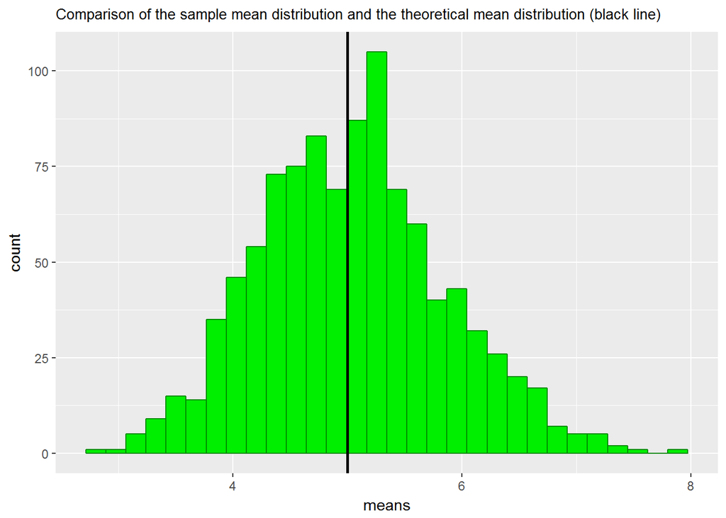

```r
g1 <-ggplot(as.data.frame(means), aes(x=means))+
        geom_histogram(col="green4", fill="green2" )+
        geom_vline(xintercept=meanDist, col="black", size=1)+
        labs(title="Comparison of the sample mean distribution and the theoretical mean distribution (black line) ")+
        theme(plot.title= element_text(size=10))
g1
```

The difference between the Sample mean (5.041252) and the theoretical distribution mean (5) is 0.825 %, so the means are almost identical.

As we can observe in the histogram, the theoretical mean is almost identical to the sample mean.

#### Point 2: Variance comparison

```r
stdDist <- (1/lam)
stdErr <- stdDist/sqrt(n)
stdSample <- sd(means)
varDist <- stdErr^2
varSample <- stdSample^2

error2 <- (varSample- varDist)/varDist *100
error2 <- round(error2, digits=3)
```

The difference between the Sample variance (0.6562493) and the theoretical distribution variance (0.625) is 5 %, so the varaiances are almost identical.

#### Point 3: Exponenetial vs Normal distributions

For this point we plot the histogram of the exponential sample means with its density function and add the Normal density function to compare both.

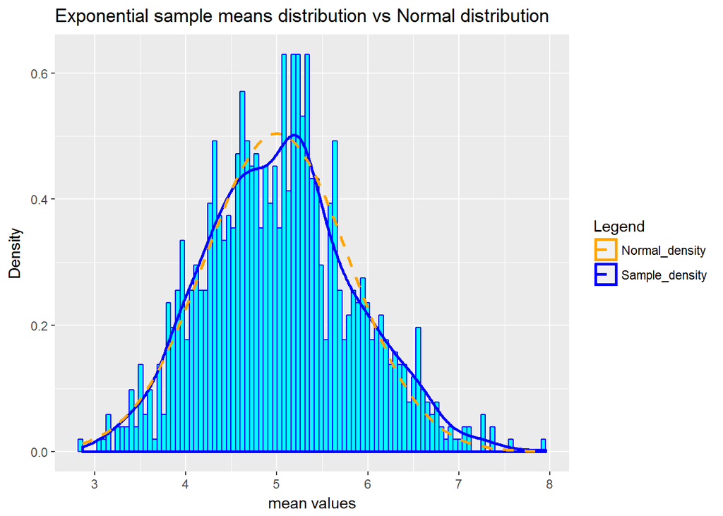

```r
width= (max(means) -min(means))/100
means <- as.data.frame(means)
g <- ggplot(means, aes(x=means))
g+ geom_histogram(aes(y=..density..), color="blue", fill="cyan", binwidth = width)+
        geom_density(aes(col="Sample_density"), size=1)+
        stat_function(fun=dnorm, args=list(mean=meanDist, sd=stdErr),aes(col="Normal_density"), linetype=2, size=1)+
        labs(title="Exponential sample means distribution vs Normal distribution")+
        labs(x="mean values")+
        labs(y="Density")+
        scale_color_manual(name="Legend", values=c(Sample_density="blue", Normal_density="orange"))
```

As it can be observed, the distirbution of exponential sample means is very much like the Normal distribution, which is due to the **Central Limit Theorem**. If we would increase the number of samples the exponential sample mean distribution would be almost identical to the Normal distribution.